# ER_Groupanalysis

Import libraries

```r
library(readxl)
library(rstatix)
library(ggplot2)
library(apaTables)
library(ez)
library(dplyr)
library(tidyr)
library(car)
library(emmeans)
library(ggplot2)
```

Import dataset

```r
data <- read_excel("C:/Users/juhoffmann/Desktop/Git/UnconsciousBias/data/BackwardMask_Questionnaire_Results_CERQ.xlsx",
     col_types = c("text", "numeric", "numeric",
         "numeric", "numeric", "numeric",
         "numeric", "numeric", "numeric",
         "numeric", "numeric", "numeric",
         "numeric"))
```

Rename columns

```r
data <- data

colnames(data)[colnames(data) == "name"] ="participant"
colnames(data)[colnames(data) == "Alter"] ="age"
colnames(data)[colnames(data) == "Gender_f1_m2"] ="sex"
colnames(data)[colnames(data) == "Group_MDD1_HC2"] ="group"

# functional emotion regulation strategies
colnames(data)[colnames(data) == "CERQ_Relativieren"] ="CERQ_putting_into_perspective"
colnames(data)[colnames(data) == "CERQ_Positive Refokussierung"] ="CERQ_positive_reinforcement"
colnames(data)[colnames(data) == "CERQ_Positive Neubewertung"] ="CERQ_positive_reappraisal"
colnames(data)[colnames(data) == "CERQ_Refokussierung auf Planung"] ="CERQ_refocus_on_planning"
colnames(data)[colnames(data) == "CERQ_Akzeptanz"] ="CERQ_acceptance"
# dysfunctional emotion regulation strategies
colnames(data)[colnames(data) == "CERQ_Selbstbeschuldigung"] ="CERQ_self_blame"
colnames(data)[colnames(data) == "CERQ_Rumination"] ="CERQ_rumination"
colnames(data)[colnames(data) == "CERQ_Katastrophisierung"] ="CERQ_catastrophizing"
colnames(data)[colnames(data) == "CERQ_Andere Beschuldigen"] ="CERQ_blaming_others"
```

```r
data$functional_score = rowMeans(data[, c("CERQ_putting_into_perspective", "CERQ_positive_reinforcement",  "CERQ_positive_reappraisal", "CERQ_refocus_on_planning", "CERQ_acceptance")], na.rm = TRUE)
data$dysfunctional_score = rowMeans(data[, c("CERQ_self_blame", "CERQ_rumination", "CERQ_catastrophizing", "CERQ_blaming_others")], na.rm = TRUE)
```

Median split approach

```r
# Identifying median values
median_functional = median(data$functional_score, na.rm = TRUE)
median_dysfunctional = median(data$dysfunctional_score, na.rm = TRUE)

# Sorting participants
data$ERgroup = with(data, ifelse(functional_score >= median_functional & dysfunctional_score < median_dysfunctional, "Functional",
                               ifelse(functional_score < median_functional & dysfunctional_score >= median_dysfunctional, "Dysfunctional", "Mixed")))
```

```r
table(data$group, data$ERgroup)
```

```
    Dysfunctional Functional Mixed
  1            38          3    18
  2             4         37    23
```

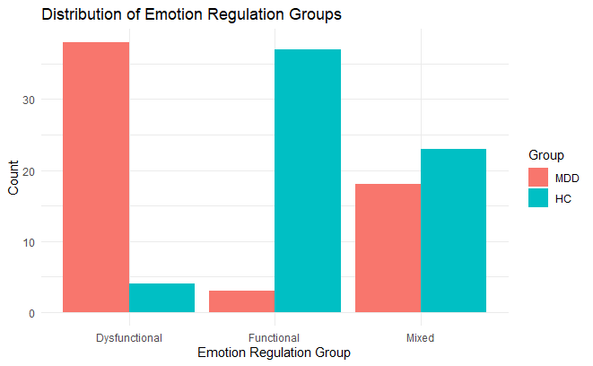

```r
library(ggplot2)

# Converting 'group' to a factor for clearer labels in the plot
data$group <- factor(data$group, levels = c(1, 2), labels = c("MDD", "HC"))

ggplot(data, aes(x = ERgroup, fill = group)) +
  geom_bar(position = "dodge") +
  labs(title = "Distribution of Emotion Regulation Groups",
       x = "Emotion Regulation Group",
       y = "Count",
       fill = "Group") +
  theme_minimal()
```

Statistical tests to see if the distribution across ER groups significantly differs between MDD patients and healthy controls. This will test the null hypothesis that there is no association between the participant group (MDD vs. HC) and their ER group (Dysfunctional, Mixed, Functional)

```r
chisq.test(table(data$group, data$ERgroup))
```

```
    Pearson's Chi-squared test

data:  table(data$group, data$ERgroup)
X-squared = 56.924, df = 2, p-value = 4.355e-13
```

# Clustering

Prepare Data: Scale ER strategy scores to ensure they’re on the same scale, which is important for clustering.

```r
scores_scaled <- scale(data[, c("CERQ_self_blame", "CERQ_rumination", "CERQ_catastrophizing", "CERQ_blaming_others", "CERQ_putting_into_perspective", "CERQ_positive_reinforcement", "CERQ_positive_reappraisal", "CERQ_refocus_on_planning", "CERQ_acceptance")])
```

Use the NbClust package for determining the number of clusters, which offers a wide range of methods:

```
*** : The Hubert index is a graphical method of determining the number of clusters.
                In the plot of Hubert index, we seek a significant knee that corresponds to a
                significant increase of the value of the measure i.e the significant peak in Hubert
                index second differences plot.
```

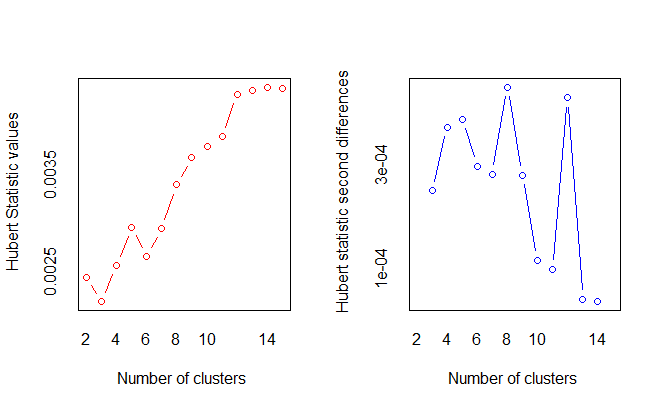

```
*** : The D index is a graphical method of determining the number of clusters.
                In the plot of D index, we seek a significant knee (the significant peak in Dindex
                second differences plot) that corresponds to a significant increase of the value of
                the measure.

* Among all indices:
* 11 proposed 2 as the best number of clusters
* 1 proposed 3 as the best number of clusters
* 1 proposed 4 as the best number of clusters
* 1 proposed 5 as the best number of clusters
* 6 proposed 8 as the best number of clusters
* 1 proposed 11 as the best number of clusters
* 1 proposed 13 as the best number of clusters
* 1 proposed 14 as the best number of clusters
* 1 proposed 15 as the best number of clusters

                   ***** Conclusion *****

* According to the majority rule, the best number of clusters is  2
```

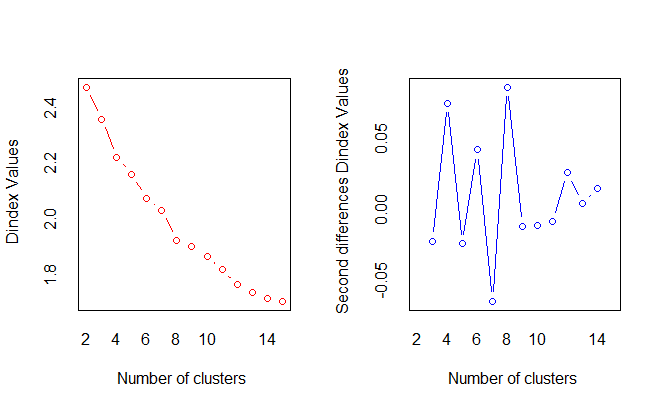

```r
#install.packages("NbClust")
library(NbClust)
data2 <- scores_scaled  # Assuming this is your prepared data
nb <- NbClust(data2, distance = "euclidean", min.nc = 2, max.nc = 15, method = "kmeans")
```

-> chose 2 Cluster

Apply k-means clustering with the determined number of clusters:

```r
set.seed(123)  # for reproducibility
k <- 2  # assuming the optimal number of clusters is 2
kmeans_result <- kmeans(scores_scaled, centers = k, nstart = 25)
```

Add the cluster assignments back to your original dataframe:

```r
data$cluster <- kmeans_result$cluster
```

```r
table(data$group, data$cluster)
```

```
       1  2
  MDD 20 39
  HC  59  5
```

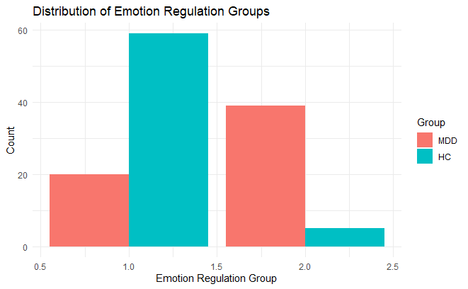

```r
# Converting 'group' to a factor for clearer labels in the plot

data$group <- factor(data$group, labels = c("MDD", "HC"))

ggplot(data, aes(x = cluster, fill = group)) +
  geom_bar(position = "dodge") +
  labs(title = "Distribution of Emotion Regulation Groups",
       x = "Emotion Regulation Group",
       y = "Count",
       fill = "Group") +
  theme_minimal()
```

## switch dysfunctional CERQ items into negative scores

```r
data <- data %>%
  mutate(CERQ_self_blame_neg = if_else(CERQ_self_blame > 0, CERQ_self_blame * -1, CERQ_self_blame),
         CERQ_rumination_neg = if_else(CERQ_rumination > 0, CERQ_rumination * -1, CERQ_rumination),
         CERQ_catastrophizing_neg = if_else(CERQ_catastrophizing > 0, CERQ_catastrophizing * -1, CERQ_catastrophizing),
         CERQ_blaming_others_neg = if_else(CERQ_blaming_others > 0, CERQ_blaming_others * -1, CERQ_blaming_others))
```

Prepare Data: Scale ER strategy scores to ensure they’re on the same scale, which is important for clustering.

```r
scores_scaled <- scale(data[, c("CERQ_self_blame_neg", "CERQ_rumination_neg", "CERQ_catastrophizing_neg", "CERQ_blaming_others_neg", "CERQ_putting_into_perspective", "CERQ_positive_reinforcement", "CERQ_positive_reappraisal", "CERQ_refocus_on_planning", "CERQ_acceptance")])
```

Use the NbClust package for determining the number of clusters, which offers a wide range of methods:

```
*** : The Hubert index is a graphical method of determining the number of clusters.
                In the plot of Hubert index, we seek a significant knee that corresponds to a
                significant increase of the value of the measure i.e the significant peak in Hubert
                index second differences plot.
```

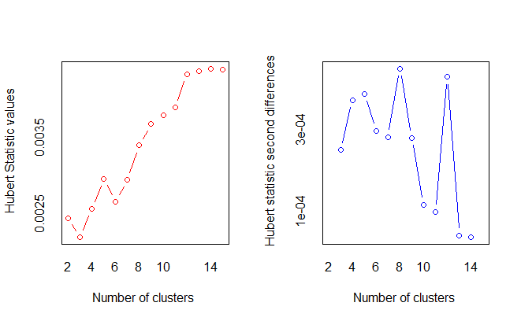

```
*** : The D index is a graphical method of determining the number of clusters.
                In the plot of D index, we seek a significant knee (the significant peak in Dindex
                second differences plot) that corresponds to a significant increase of the value of
                the measure.

* Among all indices:
* 11 proposed 2 as the best number of clusters
* 2 proposed 3 as the best number of clusters
* 1 proposed 5 as the best number of clusters
* 6 proposed 8 as the best number of clusters
* 1 proposed 11 as the best number of clusters
* 1 proposed 13 as the best number of clusters
* 1 proposed 14 as the best number of clusters
* 1 proposed 15 as the best number of clusters

                   ***** Conclusion *****

* According to the majority rule, the best number of clusters is  2
```

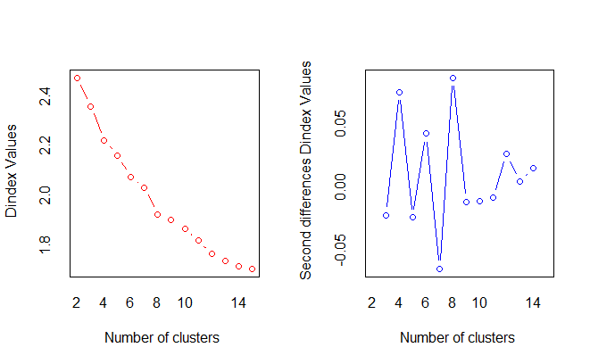

```r
#install.packages("NbClust")
library(NbClust)
data2 <- scores_scaled  # Assuming this is your prepared data
nb <- NbClust(data2, distance = "euclidean", min.nc = 2, max.nc = 15, method = "kmeans")
```

-> chose 2 Cluster

Apply k-means clustering with the determined number of clusters:

```r
set.seed(123)  # for reproducibility
k <- 2  # assuming the optimal number of clusters is 2
kmeans_result <- kmeans(scores_scaled, centers = k, nstart = 25)
```

Add the cluster assignments back to your original dataframe:

```r
data$cluster <- kmeans_result$cluster
```

```r
table(data$group, data$cluster)
```

```
       1  2
  MDD 20 39
  HC  59  5
```

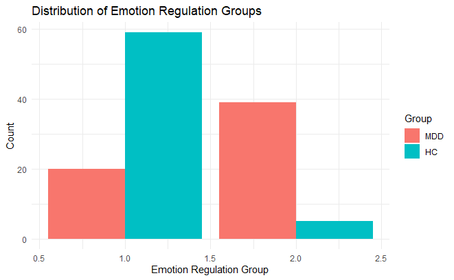

```r
# Converting 'group' to a factor for clearer labels in the plot

data$group <- factor(data$group, labels = c("MDD", "HC"))

ggplot(data, aes(x = cluster, fill = group)) +
  geom_bar(position = "dodge") +
  labs(title = "Distribution of Emotion Regulation Groups",
       x = "Emotion Regulation Group",
       y = "Count",
       fill = "Group") +
  theme_minimal()
```

```r
cerq_scores_by_cluster <- data %>%
  group_by(cluster) %>%
  summarise(across(ends_with("score"),mean,na.rm = TRUE))
```

```r
print(cerq_scores_by_cluster)
```

| cluster | functional_score | dysfunctional_score |
| --- | --- | --- |
| 1 | 13.931646 | 8.417722 |
| 2 | 9.763636 | 10.971591 |

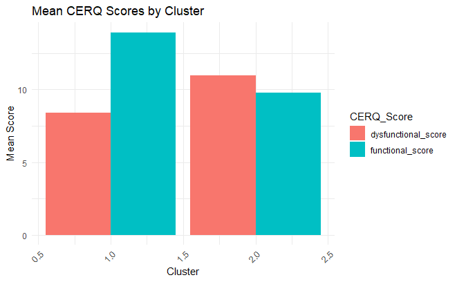

```r
library(ggplot2)

cerq_scores_by_cluster_long <- cerq_scores_by_cluster %>%
  pivot_longer(-cluster, names_to = "CERQ_Score", values_to = "Value")

ggplot(cerq_scores_by_cluster_long, aes(x = cluster, y = Value, fill = CERQ_Score)) +
  geom_bar(stat = "identity", position = position_dodge()) +
  theme_minimal() +
  labs(title = "Mean CERQ Scores by Cluster",
       x = "Cluster",
       y = "Mean Score") +
  theme(axis.text.x = element_text(angle = 45, hjust = 1))
```